# Strawberries_Assignment

2024-10-02

# Preparing data for analysis

### Data cleaning and organization

Cleaning and organizing data for analysis is an essential skill for data scientists. Serious data analyses must be presented with the data on which the results depend. The credibility of data analysis and modelling depends on the care taken in data preparation and organization.

## USDA NASS

```r
library(knitr)
library(kableExtra)
library(tidyverse)
library(stringr)
```

```r
strawberry <- read_csv("strawberries25_v3.csv", col_names = TRUE)
glimpse(strawberry)
```

```
## Rows: 12,669
## Columns: 21
## $ Program            <chr> "CENSUS", "CENSUS", "CENSUS", "CENSUS", "CENSUS", "…
## $ Year               <dbl> 2022, 2022, 2022, 2022, 2022, 2022, 2022, 2022, 202…
## $ Period             <chr> "YEAR", "YEAR", "YEAR", "YEAR", "YEAR", "YEAR", "YE…
## $ `Week Ending`      <lgl> NA, NA, NA, NA, NA, NA, NA, NA, NA, NA, NA, NA, NA,…
## $ `Geo Level`        <chr> "COUNTY", "COUNTY", "COUNTY", "COUNTY", "COUNTY", "…
## $ State              <chr> "ALABAMA", "ALABAMA", "ALABAMA", "ALABAMA", "ALABAM…
## $ `State ANSI`       <chr> "01", "01", "01", "01", "01", "01", "01", "01", "01…
## $ `Ag District`      <chr> "BLACK BELT", "BLACK BELT", "BLACK BELT", "BLACK BE…
## $ `Ag District Code` <dbl> 40, 40, 40, 40, 40, 40, 40, 40, 40, 40, 40, 40, 40,…
## $ County             <chr> "BULLOCK", "BULLOCK", "BULLOCK", "BULLOCK", "BULLOC…
## $ `County ANSI`      <chr> "011", "011", "011", "011", "011", "011", "101", "1…
## $ `Zip Code`         <lgl> NA, NA, NA, NA, NA, NA, NA, NA, NA, NA, NA, NA, NA,…
## $ Region             <lgl> NA, NA, NA, NA, NA, NA, NA, NA, NA, NA, NA, NA, NA,…
## $ watershed_code     <chr> "00000000", "00000000", "00000000", "00000000", "00…
## $ Watershed          <lgl> NA, NA, NA, NA, NA, NA, NA, NA, NA, NA, NA, NA, NA,…
## $ Commodity          <chr> "STRAWBERRIES", "STRAWBERRIES", "STRAWBERRIES", "ST…
## $ `Data Item`        <chr> "STRAWBERRIES - ACRES BEARING", "STRAWBERRIES - ACR…
## $ Domain             <chr> "TOTAL", "TOTAL", "TOTAL", "TOTAL", "TOTAL", "TOTAL…
## $ `Domain Category`  <chr> "NOT SPECIFIED", "NOT SPECIFIED", "NOT SPECIFIED", …
## $ Value              <chr> "(D)", "3", "(D)", "1", "6", "5", "(D)", "(D)", "2"…
## $ `CV (%)`           <chr> "(D)", "15.7", "(D)", "(L)", "52.7", "47.6", "(D)",…
```

```r
## is every line associated with a state?

state_all <- strawberry |> distinct(State)

state_all1 <- strawberry |> group_by(State) |> count()

## every row is associated with a state

sum(state_all1$n) == dim(strawberry)[1]
```

```
## [1] TRUE
```

```r
## to get an idea of the data -- looking at california only

calif_census <- strawberry |> filter((State=="CALIFORNIA") & (Program=="CENSUS"))

calif_census <- calif_census |> select(Year, `Data Item`, Value)

###

calif_survey <- strawberry |> filter((State=="CALIFORNIA") & (Program=="SURVEY"))

calif_survey <- strawberry |> select(Year, Period, `Data Item`, Value)
```

## remove columns with a single value in all columns

```r
#|label: drop 1-item columns

drop_one_value_col <- function(df){
drop <- NULL
for(i in 1:dim(df)[2]){
if((df |> distinct(df[,i]) |> count()) == 1){
drop = c(drop, i)
} }

if(is.null(drop)){return("none")}else{

   print("Columns dropped:")
   print(colnames(df)[drop])
   strawberry <- df[, -1*drop]
   }
}


## use the function

strawberry <- drop_one_value_col(strawberry)
```

```
## [1] "Columns dropped:"
## [1] "Week Ending"    "Zip Code"       "Region"         "watershed_code"
## [5] "Watershed"      "Commodity"
```

```r
drop_one_value_col(strawberry)
```

```
## [1] "none"
```

## separate composite columns

### `Data Item` into (fruit, category, item)

```r
#|label: split Data Item

  strawberry <- strawberry |>
  separate_wider_delim(  cols = `Data Item`,
                         delim = ",",
                         names = c("Fruit",
                                 "Category",
                                 "Item",
                                 "Metric"),
                         too_many = "error",
                         too_few = "align_start"
                       )

## Use too_many and too_few to set up the separation operation.

# Save the updated dataframe to a new CSV file


#|label: fix the leading space

 # note
strawberry$Category[1]
```

```
## [1] NA
```

```r
# strawberry$Item[2]
# strawberry$Metric[6]
# strawberry$Domain[1]
##
## trim white space

strawberry$Category <- str_trim(strawberry$Category, side = "both")
strawberry$Item <- str_trim(strawberry$Item, side = "both")
strawberry$Metric <- str_trim(strawberry$Metric, side = "both")


write.csv(strawberry, file = "strawberry_separated.csv", row.names = FALSE)

#|label: fix the leading space

 # note
strawberry$Category[1]
```

```
## [1] NA
```

```r
# strawberry$Item[2]
# strawberry$Metric[6]
# strawberry$Domain[1]
##
## trim white space

strawberry$Category <- str_trim(strawberry$Category, side = "both")
strawberry$Item <- str_trim(strawberry$Item, side = "both")
strawberry$Metric <- str_trim(strawberry$Metric, side = "both")

unique(strawberry$Fruit)
```

```
##  [1] "STRAWBERRIES - ACRES BEARING"
##  [2] "STRAWBERRIES - ACRES GROWN"
##  [3] "STRAWBERRIES - ACRES NON-BEARING"
##  [4] "STRAWBERRIES - OPERATIONS WITH AREA BEARING"
##  [5] "STRAWBERRIES - OPERATIONS WITH AREA GROWN"
##  [6] "STRAWBERRIES - OPERATIONS WITH AREA NON-BEARING"
##  [7] "STRAWBERRIES"
##  [8] "STRAWBERRIES - PRICE RECEIVED"
##  [9] "STRAWBERRIES - ACRES HARVESTED"
## [10] "STRAWBERRIES - ACRES PLANTED"
## [11] "STRAWBERRIES - PRODUCTION"
## [12] "STRAWBERRIES - YIELD"
## [13] "STRAWBERRIES - APPLICATIONS"
## [14] "STRAWBERRIES - TREATED"
```

```r
## generate a list of rows with the production and price information

spr <- which((strawberry$Fruit=="STRAWBERRIES - PRODUCTION") | (strawberry$Fruit=="STRAWBERRIES - PRICE RECEIVED"))


strw_prod_price <- strawberry |> slice(spr)


## this has the census data, too

strw_chem <- strawberry |> slice(-1*spr)


#|label: split srawberry into census and survey pieces

strw_b_sales <- strawberry |> filter(Program == "CENSUS")

strw_b_chem <- strawberry |> filter(Program == "SURVEY")

nrow(strawberry) == (nrow(strw_b_chem) + nrow(strw_b_sales))
```

```
## [1] TRUE
```

```r
## Move marketing-related rows in strw_b_chem
## to strw_b_sales


write.csv(strawberry, file = "strawberry_separated.csv", row.names = FALSE)
```

```r
# Load required libraries
library(tidyverse)

# Step 1: Read the CSV file
strawberry <- read_csv("strawberry_separated.csv")
# Step 2: Clean and organize the 'Use', 'Name', and 'Code' columns, and remove 'Domain' and 'Domain Category'
strawberry_clean <- strawberry %>%
  # Extract 'Use' from the 'Domain' column
  mutate(
    Use = case_when(
      str_detect(`Domain`, "FUNGICIDE") ~ "FUNGICIDE",
      str_detect(`Domain`, "INSECTICIDE") ~ "INSECTICIDE",
      str_detect(`Domain`, "HERBICIDE") ~ "HERBICIDE",
      TRUE ~ NA_character_
    ),
    # Extract 'Name' from the 'Domain Category' column, removing the '= CODE' part
    Name = str_extract(`Domain Category`, "\\((.*?)\\)"),
    Name = str_replace_all(Name, " = \\d+", ""),  # Remove the '= CODE' part
    Name = str_replace_all(Name, "[()]", ""),    # Remove parentheses around 'Name'
    # Extract 'Code' from the 'Domain Category' column (after the '=' sign)
    Code = str_extract(`Domain Category`, "\\d+"),  # Extract only the numeric part of the code
    Code = str_trim(Code)  # Clean up any remaining whitespace
  ) %>%
  # Remove rows where 'Use', 'Name', or 'Code' are NA
  drop_na(Use, Name, Code) %>%
  # Remove the unwanted 'Domain' and 'Domain Category' columns
  select(-Domain, -`Domain Category`)

# Step 3: Save the cleaned dataset to a new CSV file
write_csv(strawberry_clean, "strawberry_separated_clean.csv")

# Output to verify the cleaned data
print(strawberry_clean)
```

```
## # A tibble: 2,805 × 19
##    Program  Year Period `Geo Level` State      `State ANSI` `Ag District`
##    <chr>   <dbl> <chr>  <chr>       <chr>      <chr>        <chr>
##  1 SURVEY   2023 YEAR   STATE       CALIFORNIA 06           <NA>
##  2 SURVEY   2023 YEAR   STATE       CALIFORNIA 06           <NA>
##  3 SURVEY   2023 YEAR   STATE       CALIFORNIA 06           <NA>
##  4 SURVEY   2023 YEAR   STATE       CALIFORNIA 06           <NA>
##  5 SURVEY   2023 YEAR   STATE       CALIFORNIA 06           <NA>
##  6 SURVEY   2023 YEAR   STATE       CALIFORNIA 06           <NA>
##  7 SURVEY   2023 YEAR   STATE       CALIFORNIA 06           <NA>
##  8 SURVEY   2023 YEAR   STATE       CALIFORNIA 06           <NA>
##  9 SURVEY   2023 YEAR   STATE       CALIFORNIA 06           <NA>
## 10 SURVEY   2023 YEAR   STATE       CALIFORNIA 06           <NA>
## # ℹ 2,795 more rows
## # ℹ 12 more variables: `Ag District Code` <dbl>, County <chr>,
## #   `County ANSI` <chr>, Fruit <chr>, Category <chr>, Item <chr>, Metric <chr>,
## #   Value <chr>, `CV (%)` <chr>, Use <chr>, Name <chr>, Code <chr>
```

```r
# Display the first few rows of the cleaned data as a table
knitr::kable(head(strawberry_clean), format = "html") %>%
  kableExtra::kable_styling(bootstrap_options = c("striped", "hover", "condensed"))
```

Program

Year

Period

Geo Level

State

State ANSI

Ag District

Ag District Code

County

County ANSI

Fruit

Category

Item

Metric

Value

CV (%)

Use

Name

Code

SURVEY

2023

YEAR

STATE

CALIFORNIA

06

NA

NA

NA

NA

STRAWBERRIES - APPLICATIONS

MEASURED IN LB

NA

NA

NA

FUNGICIDE

OXATHIAPIPROLIN

128111

SURVEY

2023

YEAR

STATE

CALIFORNIA

06

NA

NA

NA

NA

STRAWBERRIES - APPLICATIONS

MEASURED IN LB

NA

NA

NA

INSECTICIDE

CYCLANILIPROLE

26202

SURVEY

2023

YEAR

STATE

CALIFORNIA

06

NA

NA

NA

NA

STRAWBERRIES - APPLICATIONS

MEASURED IN LB

NA

NA

NA

INSECTICIDE

PERMETHRIN

109701

SURVEY

2023

YEAR

STATE

CALIFORNIA

06

NA

NA

NA

NA

STRAWBERRIES - APPLICATIONS

MEASURED IN LB / ACRE / APPLICATION

AVG

NA

NA

FUNGICIDE

OXATHIAPIPROLIN

128111

SURVEY

2023

YEAR

STATE

CALIFORNIA

06

NA

NA

NA

NA

STRAWBERRIES - APPLICATIONS

MEASURED IN LB / ACRE / APPLICATION

AVG

NA

NA

INSECTICIDE

CYCLANILIPROLE

26202

SURVEY

2023

YEAR

STATE

CALIFORNIA

06

NA

NA

NA

NA

STRAWBERRIES - APPLICATIONS

MEASURED IN LB / ACRE / APPLICATION

AVG

NA

NA

INSECTICIDE

PERMETHRIN

109701

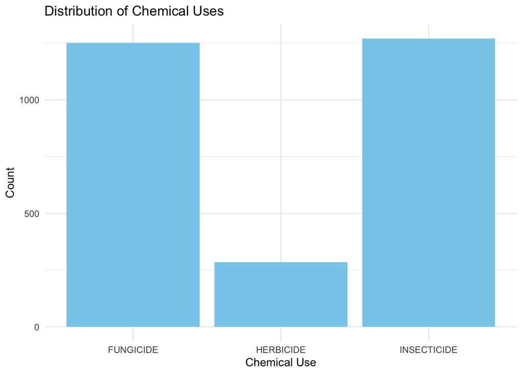

```r
# Bar plot of chemical use types (FUNGICIDE, INSECTICIDE, etc.)
ggplot(strawberry_clean, aes(x = Use)) +
  geom_bar(fill = "skyblue") +
  labs(title = "Distribution of Chemical Uses", x = "Chemical Use", y = "Count") +
  theme_minimal()
```

From this outcome, we can assume that Fungicide and Insecticide are commonly used in the strawberry growing process events.

From this, we could investigate the reasons as of why herbicdes are used less, or explore trends on how the usage of three have changed in the recent years.

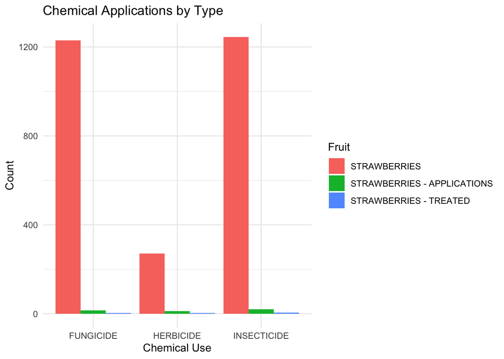

```r
# Plot the number of chemical applications (grouped by 'Use') across different measurement types
ggplot(strawberry_clean, aes(x = Use, fill = Fruit)) +
  geom_bar(position = "dodge") +
  labs(title = "Chemical Applications by Type", x = "Chemical Use", y = "Count", fill = "Fruit") +
  theme_minimal()
```

From the graph above, we notice that Strawberries - applications and strawberries - treated are both contributing minimally accross the chemical types. These may show that there are different chemicals or specialized treatment methods for crop treatments.

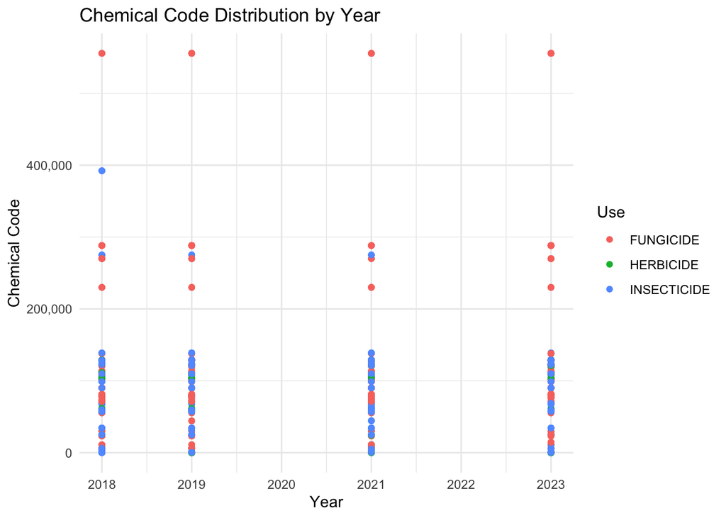

```r
# Load the necessary libraries
library(tidyverse)

# Assuming 'strawberry_clean' is the cleaned dataset with 'Year', 'Code', and 'Use' columns
ggplot(strawberry_clean, aes(x = Year, y = as.numeric(Code), color = Use)) +
  geom_point() +
  labs(title = "Chemical Code Distribution by Year", x = "Year", y = "Chemical Code") +
  scale_y_continuous(labels = scales::comma) +  # This will format the y-axis with commas instead of scientific notation
  theme_minimal()
```